# EDA_Credit_risk_project

Astha K C

2025-09-19

# A clear statement of the business and analytic problems for the project

Business problem: Many people struggle to get loans due to insufficient or non existent credit histories. Even though the credit is using various methods to make predictions they are are facing challenges of accurately assessing the repayment ability of clients.The goal is to help the company reduce financial risk by predicting which loan applicants are most likely to default. Analytic problem: The analytic task is to build a predictive model that uses applicant information to estimate the likelihood of default.

The target variable is TARGET, where 0 = the client repaid the loan (no default) 1 = the client defaulted on the loan

EDA shows that the data is unbalanced, with fewer defaults than non- defaults. We also found some predictors that look promising ad some data issue that will need to be addesed before modelling.

# Questions to guide your exploration

1.Is the target variable TARGET balanced or imbalanced? 2.What would accuracy be if we always predicted the majority class? 3.How do key demographics age, education, family status relate to default? 4.Does employment history years employed, occupation typ affect default rates? 5.How does income compare between defaulters and non-defaulters? 6.Is loan size (credit amount, annuity) related to default? 7.Do external risk scores (EXT_SOURCE_1, EXT_SOURCE_2, EXT_SOURCE_3) strongly separate defaulters from non-defaulters? 8.Which variables have large amounts of missing data, and how should they be treated? 9.Are there strange or unrealistic values ? 10.Are there features with near-zero variance that should be dropped? 11.Do features from transaction data (bureau, previous applications) add predictive signal?

Which 15–20 features look most promising from data exploration? # Install and load the packages.

```r
library(tidyverse)
library(data.table)
library(janitor)
library(skimr)
library(naniar)
```

```r
library(ggplot2)
library(ggthemes)
library(VennDiagram)
```

# Import data

```r
train <- read_csv("application_train.csv")
test <- read_csv("application_test.csv")
bureau <- read_csv("bureau.csv")
```

# Exploring the target variable.

```r
#  For counts and proportions
table(train$TARGET)
```

```
##
##      0      1
## 282686  24825
```

```r
prop.table(table(train$TARGET))
```

```
##
##          0          1
## 0.91927118 0.08072882
```

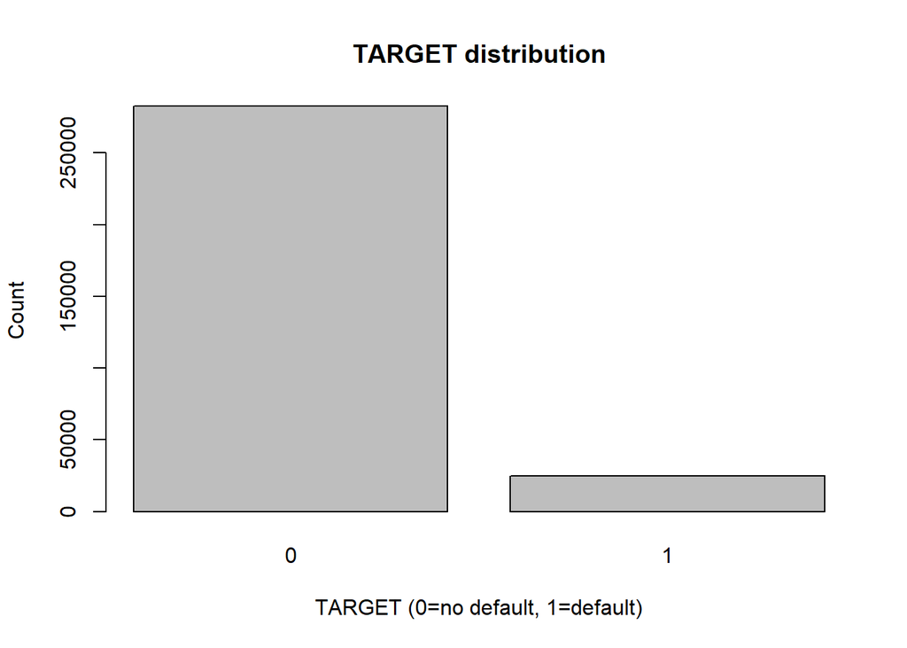

```r
# Now plot
barplot(table(train$TARGET),
        main="TARGET distribution",
        xlab="TARGET (0=no default, 1=default)",
        ylab="Count")
```

```r
# majority baseline accuracy
max(prop.table(table(train$TARGET)))
```

```
## [1] 0.9192712
```

Yes, with respect to the target it seemed that the data is very unblanced because loan to be non- default seems to have 92 percentage while loan default is only 8 percentage. This means that data set is heavily tilted towards non defaults. The majority class classifier would be Target 0 which is non- defaults having high percentage accuracy.

# Explore the relationship between target and predictors.

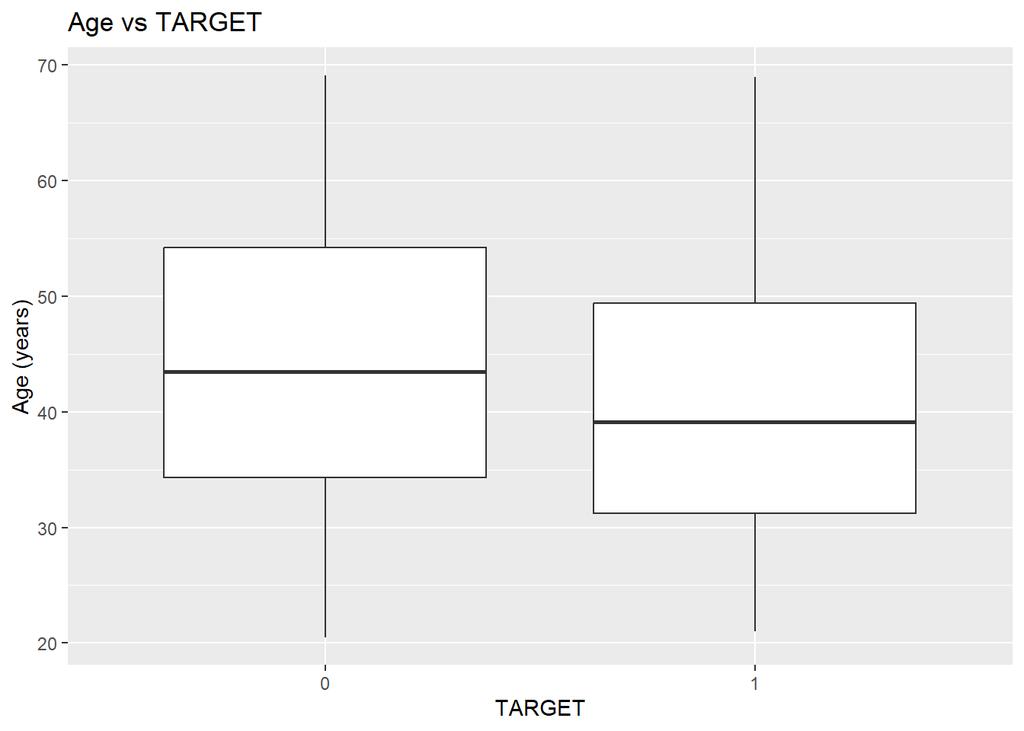

```r
# Age
train$AGE_YEARS <- abs(train$DAYS_BIRTH)/365
train$EDUCATION_TYPE <- (train$NAME_EDUCATION_TYPE)
train$EXT_SOURCE <- (train$EXT_SOURCE_2)

# Now plot
# Age and Target
ggplot(train, aes(x=factor(TARGET), y=AGE_YEARS)) +
  geom_boxplot() +
  labs(title="Age vs TARGET",
       x="TARGET",
       y="Age (years)")
```

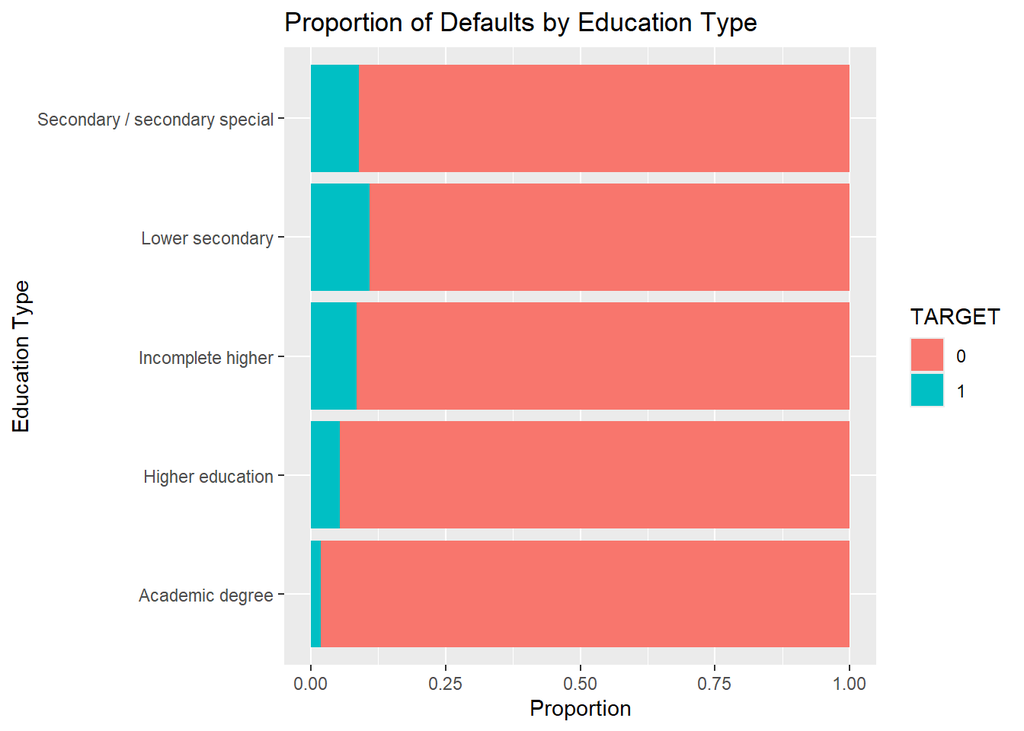

```r
# EDUCATION and TARGET
ggplot(train, aes(x=NAME_EDUCATION_TYPE, fill=factor(TARGET))) +
  geom_bar(position="fill") +
  labs(title="Proportion of Defaults by Education Type",
       x="Education Type",
       y="Proportion",
       fill="TARGET") +
  coord_flip()
```

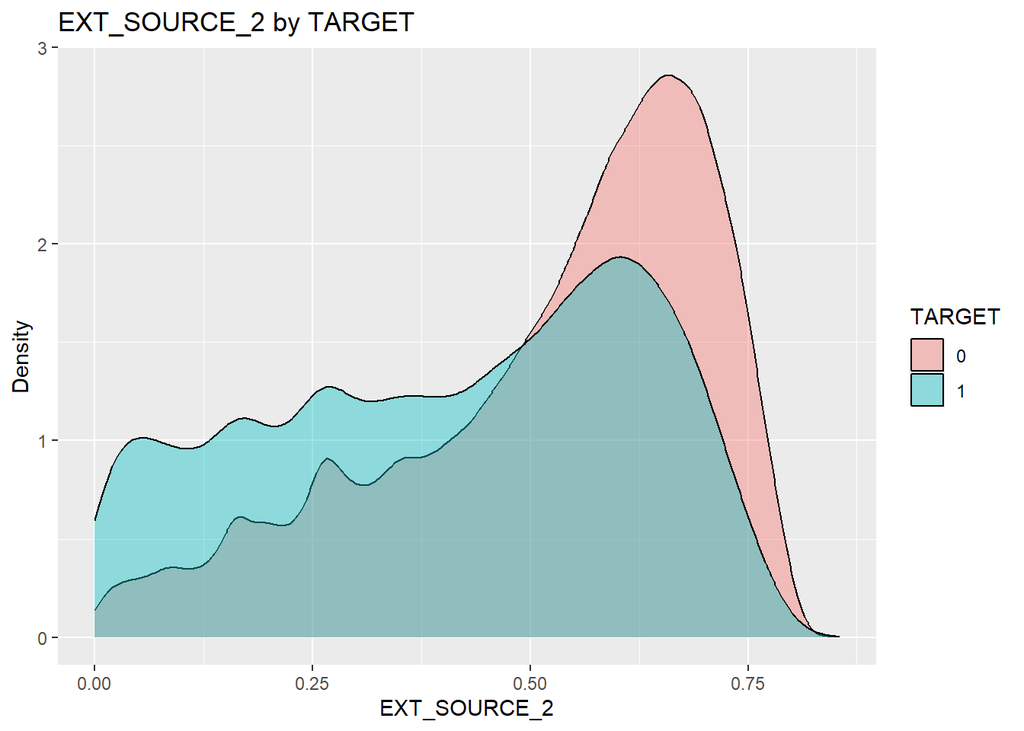

```r
# EXT_SOURCE_2 and TARGET
ggplot(train, aes(x=EXT_SOURCE_2, fill=factor(TARGET))) +
  geom_density(alpha=0.4)+
  labs(title="EXT_SOURCE_2 by TARGET",
       x="EXT_SOURCE_2",
       y="Density",
       fill="TARGET")
```

# Feature Exploration; AI vs Human

Act as a credit risk analyst. Based only on the column names and descriptions in the Home Credit Default Risk data dictionary (ignore the actual data values), identify the top 15–20 variables you believe would be most predictive of TARGET (1 = default, 0 = non-default). Avoid variables that could leak the target (post-application outcomes). Briefly explain why each might matter.

# 20 variables which would be most predictive of TARGET

1. EXT_SOURCE_1 – external credit score
2. EXT_SOURCE_2 – another external score
3. EXT_SOURCE_3 – third-party score
4. AMT_CREDIT – loan amount requested
5. AMT_ANNUITY – repayment amount relative to income
6. AMT_INCOME_TOTAL – total household income
7. AMT_GOODS_PRICE – purchase price of goods, loan-to-value ratio
8. DAYS_BIRTH – applicant’s age in days
9. DAYS_EMPLOYED – employment stability
10. NAME_EDUCATION_TYPE – education level
11. NAME_INCOME_TYPE – employment type
12. NAME_FAMILY_STATUS – marital status
13. REGION_RATING_CLIENT – regional risk rating
14. CNT_CHILDREN – number of children
15. OWN_CAR_AGE – proxy for wealth and stability
16. DAYS_ID_PUBLISH – recency of ID change
17. DAYS_REGISTRATION – length of residence
18. OCCUPATION_TYPE – type of occupation
19. CNT_FAM_MEMBERS – household size
20. NAME_HOUSING_TYPE – housing situation

# brief critique of its reasoning.

AI hightilighted many strong predictors such as external credit score, loan amount,income, age employment which are well for strong predictive. However, some variables like age of a car, household size are weaker and can be included as in income and employent. Some of the predictors like occupation type are missing values and also there is a special code in days emoloyed which are data issues. Overall, the variables that it picked are good.

# Data- Informed Exploration

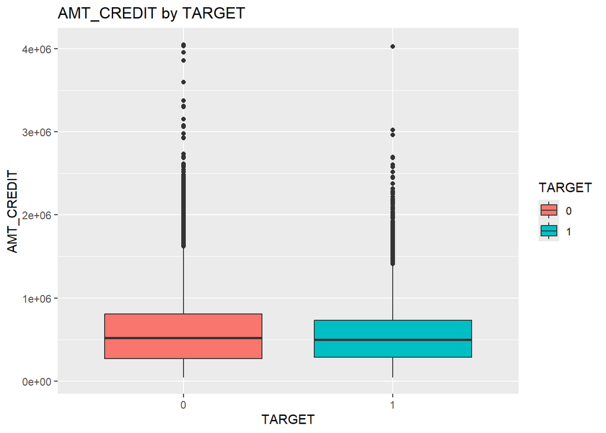

```r
# values by TARGET

train$AMT_CREDIT <- (train$AMT_CREDIT)
train$AMT_ANNUITY <- (train$AMT_ANNUITY)
train$AMT_INCOME_TOTAL <- (train$AMT_INCOME_TOTAL)

# Barplots

ggplot(train, aes(x = factor(TARGET), y = AMT_CREDIT, fill = factor(TARGET))) +
  geom_boxplot() +
  labs(title = "AMT_CREDIT by TARGET",
       x = "TARGET",
       y = "AMT_CREDIT",
       fill = "TARGET")
```

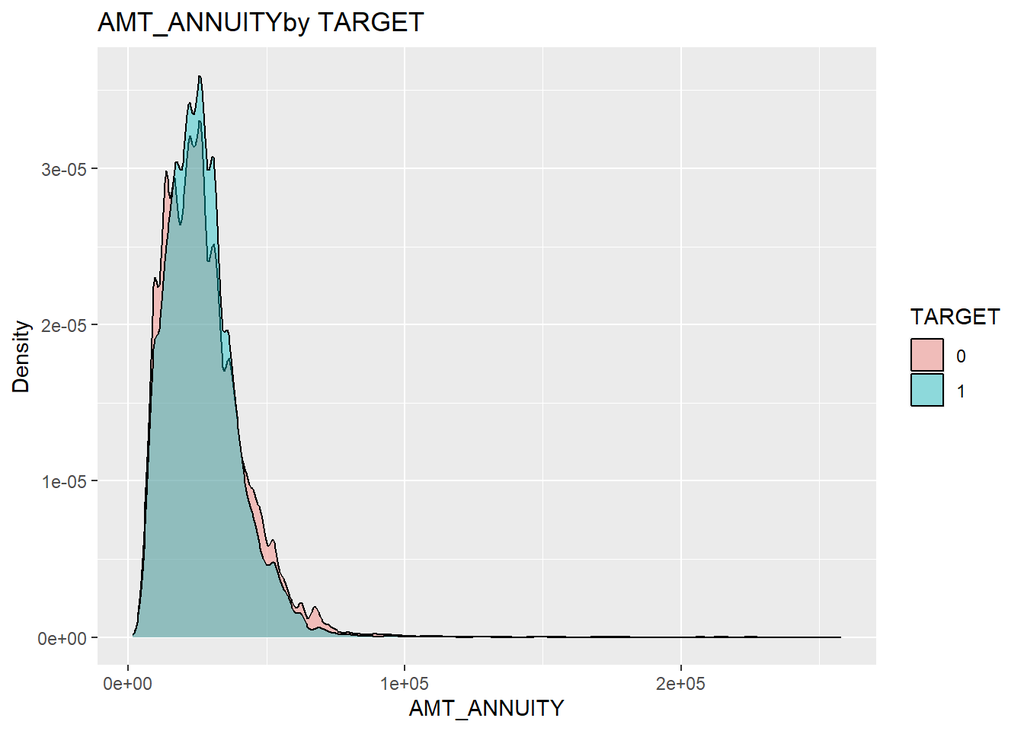

```r
ggplot(train, aes(x=AMT_ANNUITY, fill=factor(TARGET))) +
  geom_density(alpha=0.4)+
  labs(title="AMT_ANNUITYby TARGET",
       x="AMT_ANNUITY",
       y="Density",
       fill="TARGET")
```

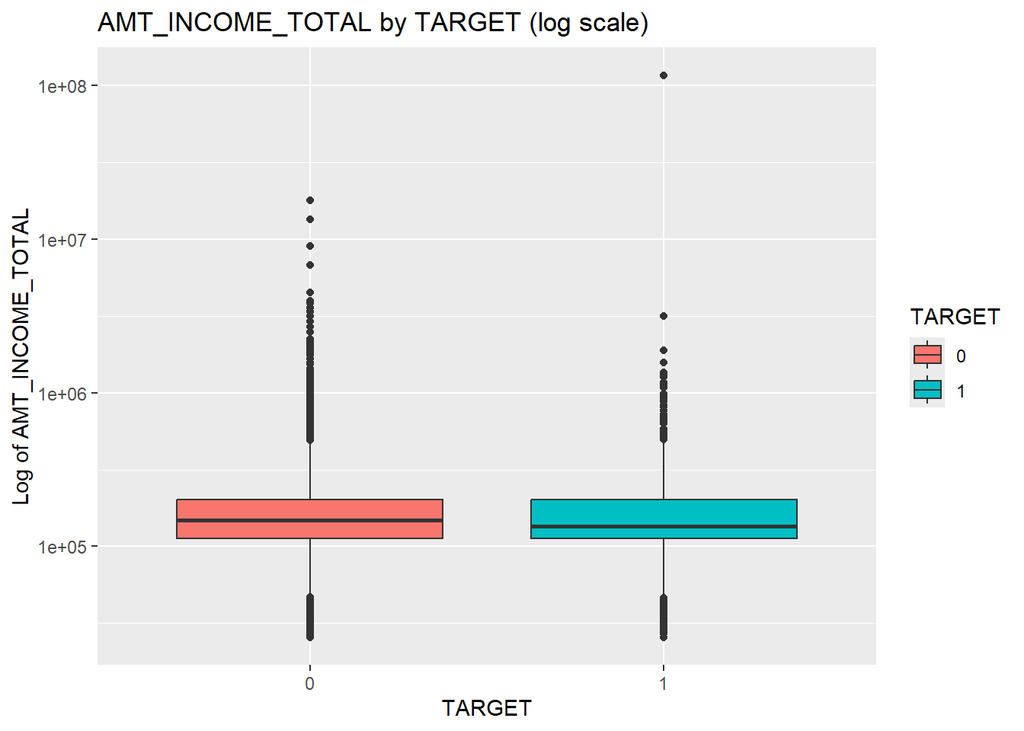

```r
ggplot(train, aes(x=factor(TARGET), y=AMT_INCOME_TOTAL, fill=factor(TARGET))) +
  geom_boxplot() +
  scale_y_log10() +
  labs(title="AMT_INCOME_TOTAL by TARGET (log scale)",
       x="TARGET", y="Log of AMT_INCOME_TOTAL", fill="TARGET")
```

The average credit amount for non- defaulters is slightly higher than for defaulters. While there is some difference, its is relatevly small. the amt annuity by TARGET shows thats most applicants have relatively small annuity values where defaulters tend to have slightly lower annuities while vice versa for non- defaulters. The income by TARGET shows that defaulters tend to have slightly lower incomes than non- defaulters but there is a heavy overlap for the distribution. This means that loan size, amount annuity is not a strong predictor compared to features like age and education level.

# list of the top 15-20 most promising predictors based on the evidence in the data.

EXT_SOURCE_1 – external risk score EXT_SOURCE_2 – external risk score EXT_SOURCE_3 – external risk score AGE_YEARS (from DAYS_BIRTH) NAME_EDUCATION_TYPE AMT_INCOME_TOTAL AMT_CREDIT AMT_ANNUITY AMT_GOODS_PRICE CREDIT/INCOME ratio ANNUITY/INCOME ratio DAYS_EMPLOYED OCCUPATION_TYPE NAME_INCOME_TYPE NAME_FAMILY_STATUS CNT_CHILDREN – more children REGION_RATING_CLIENT NAME_HOUSING_TYPE DAYS_REGISTRATION DAYS_ID_PUBLISH

# Venn diagram

```r
library(ggvenn)
```

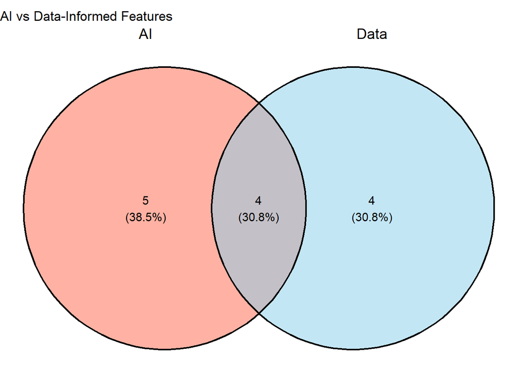

```r
library(ggplot2)

ai_list   <- c("AGE", "EDUCATION", "EXT_SOURCE_1", "EXT_SOURCE_2", "EXT_SOURCE_3",
               "INCOME", "OCCUPATION_TYPE", "CAR_AGE", "HOUSE_TYPE")
data_list <- c("AGE", "EDUCATION", "EXT_SOURCE_2", "INCOME", "ANNUITY",
               "ANNUITY/INCOME", "CREDIT/INCOME", "OVERDUE_BUREAU")
p <- ggvenn(
  list(AI = ai_list, Data = data_list),
  fill_color = c("tomato", "skyblue"),
  fill_alpha = 0.5,
  stroke_size = 0.8,
  set_name_size = 5
) + ggtitle("AI vs Data-Informed Features")
p
```

There is a significant overlap that is 31% of features overlap between the AI informed and data informed feature lists. Around 39% were AI-only, while 31% were Data-only. This highlights that AI provides a solid starting point, but data exploration uncovers additional, often stronger predictors.

# data exploration with skimr

```r
skim(train)
```

Data summary

| Name | train |
| --- | --- |
| Number of rows | 307511 |
| Number of columns | 125 |
| _______________________ |  |
| Column type frequency: |  |
| character | 17 |
| numeric | 108 |
| ________________________ |  |
| Group variables | None |

**Variable type: character**

| skim_variable | n_missing | complete_rate | min | max | empty | n_unique | whitespace |
| --- | --- | --- | --- | --- | --- | --- | --- |
| NAME_CONTRACT_TYPE | 0 | 1.00 | 10 | 15 | 0 | 2 | 0 |
| CODE_GENDER | 0 | 1.00 | 1 | 3 | 0 | 3 | 0 |
| FLAG_OWN_CAR | 0 | 1.00 | 1 | 1 | 0 | 2 | 0 |
| FLAG_OWN_REALTY | 0 | 1.00 | 1 | 1 | 0 | 2 | 0 |
| NAME_TYPE_SUITE | 1292 | 1.00 | 6 | 15 | 0 | 7 | 0 |
| NAME_INCOME_TYPE | 0 | 1.00 | 7 | 20 | 0 | 8 | 0 |
| NAME_EDUCATION_TYPE | 0 | 1.00 | 15 | 29 | 0 | 5 | 0 |
| NAME_FAMILY_STATUS | 0 | 1.00 | 5 | 20 | 0 | 6 | 0 |
| NAME_HOUSING_TYPE | 0 | 1.00 | 12 | 19 | 0 | 6 | 0 |
| OCCUPATION_TYPE | 96391 | 0.69 | 7 | 21 | 0 | 18 | 0 |
| WEEKDAY_APPR_PROCESS_START | 0 | 1.00 | 6 | 9 | 0 | 7 | 0 |
| ORGANIZATION_TYPE | 0 | 1.00 | 3 | 22 | 0 | 58 | 0 |
| FONDKAPREMONT_MODE | 210295 | 0.32 | 13 | 21 | 0 | 4 | 0 |
| HOUSETYPE_MODE | 154297 | 0.50 | 14 | 16 | 0 | 3 | 0 |
| WALLSMATERIAL_MODE | 156341 | 0.49 | 5 | 12 | 0 | 7 | 0 |
| EMERGENCYSTATE_MODE | 145755 | 0.53 | 2 | 3 | 0 | 2 | 0 |
| EDUCATION_TYPE | 0 | 1.00 | 15 | 29 | 0 | 5 | 0 |

**Variable type: numeric**

| skim_variable | n_missing | complete_rate | mean | sd | p0 | p25 | p50 | p75 | p100 | hist |
| --- | --- | --- | --- | --- | --- | --- | --- | --- | --- | --- |
| SK_ID_CURR | 0 | 1.00 | 278180.52 | 102790.18 | 100002.00 | 189145.50 | 278202.00 | 367142.50 | 456255.00 | ▇▇▇▇▇ |
| TARGET | 0 | 1.00 | 0.08 | 0.27 | 0.00 | 0.00 | 0.00 | 0.00 | 1.00 | ▇▁▁▁▁ |
| CNT_CHILDREN | 0 | 1.00 | 0.42 | 0.72 | 0.00 | 0.00 | 0.00 | 1.00 | 19.00 | ▇▁▁▁▁ |
| AMT_INCOME_TOTAL | 0 | 1.00 | 168797.92 | 237123.15 | 25650.00 | 112500.00 | 147150.00 | 202500.00 | 117000000.00 | ▇▁▁▁▁ |
| AMT_CREDIT | 0 | 1.00 | 599026.00 | 402490.78 | 45000.00 | 270000.00 | 513531.00 | 808650.00 | 4050000.00 | ▇▂▁▁▁ |
| AMT_ANNUITY | 12 | 1.00 | 27108.57 | 14493.74 | 1615.50 | 16524.00 | 24903.00 | 34596.00 | 258025.50 | ▇▁▁▁▁ |
| AMT_GOODS_PRICE | 278 | 1.00 | 538396.21 | 369446.46 | 40500.00 | 238500.00 | 450000.00 | 679500.00 | 4050000.00 | ▇▂▁▁▁ |
| REGION_POPULATION_RELATIVE | 0 | 1.00 | 0.02 | 0.01 | 0.00 | 0.01 | 0.02 | 0.03 | 0.07 | ▇▇▃▁▁ |
| DAYS_BIRTH | 0 | 1.00 | -16037.00 | 4363.99 | -25229.00 | -19682.00 | -15750.00 | -12413.00 | -7489.00 | ▃▆▇▇▅ |
| DAYS_EMPLOYED | 0 | 1.00 | 63815.05 | 141275.77 | -17912.00 | -2760.00 | -1213.00 | -289.00 | 365243.00 | ▇▁▁▁▂ |
| DAYS_REGISTRATION | 0 | 1.00 | -4986.12 | 3522.89 | -24672.00 | -7479.50 | -4504.00 | -2010.00 | 0.00 | ▁▁▂▅▇ |
| DAYS_ID_PUBLISH | 0 | 1.00 | -2994.20 | 1509.45 | -7197.00 | -4299.00 | -3254.00 | -1720.00 | 0.00 | ▁▆▇▆▅ |
| OWN_CAR_AGE | 202929 | 0.34 | 12.06 | 11.94 | 0.00 | 5.00 | 9.00 | 15.00 | 91.00 | ▇▁▁▁▁ |
| FLAG_MOBIL | 0 | 1.00 | 1.00 | 0.00 | 0.00 | 1.00 | 1.00 | 1.00 | 1.00 | ▁▁▁▁▇ |
| FLAG_EMP_PHONE | 0 | 1.00 | 0.82 | 0.38 | 0.00 | 1.00 | 1.00 | 1.00 | 1.00 | ▂▁▁▁▇ |
| FLAG_WORK_PHONE | 0 | 1.00 | 0.20 | 0.40 | 0.00 | 0.00 | 0.00 | 0.00 | 1.00 | ▇▁▁▁▂ |
| FLAG_CONT_MOBILE | 0 | 1.00 | 1.00 | 0.04 | 0.00 | 1.00 | 1.00 | 1.00 | 1.00 | ▁▁▁▁▇ |
| FLAG_PHONE | 0 | 1.00 | 0.28 | 0.45 | 0.00 | 0.00 | 0.00 | 1.00 | 1.00 | ▇▁▁▁▃ |
| FLAG_EMAIL | 0 | 1.00 | 0.06 | 0.23 | 0.00 | 0.00 | 0.00 | 0.00 | 1.00 | ▇▁▁▁▁ |
| CNT_FAM_MEMBERS | 2 | 1.00 | 2.15 | 0.91 | 1.00 | 2.00 | 2.00 | 3.00 | 20.00 | ▇▁▁▁▁ |
| REGION_RATING_CLIENT | 0 | 1.00 | 2.05 | 0.51 | 1.00 | 2.00 | 2.00 | 2.00 | 3.00 | ▁▁▇▁▂ |
| REGION_RATING_CLIENT_W_CITY | 0 | 1.00 | 2.03 | 0.50 | 1.00 | 2.00 | 2.00 | 2.00 | 3.00 | ▁▁▇▁▂ |
| HOUR_APPR_PROCESS_START | 0 | 1.00 | 12.06 | 3.27 | 0.00 | 10.00 | 12.00 | 14.00 | 23.00 | ▁▃▇▆▁ |
| REG_REGION_NOT_LIVE_REGION | 0 | 1.00 | 0.02 | 0.12 | 0.00 | 0.00 | 0.00 | 0.00 | 1.00 | ▇▁▁▁▁ |
| REG_REGION_NOT_WORK_REGION | 0 | 1.00 | 0.05 | 0.22 | 0.00 | 0.00 | 0.00 | 0.00 | 1.00 | ▇▁▁▁▁ |
| LIVE_REGION_NOT_WORK_REGION | 0 | 1.00 | 0.04 | 0.20 | 0.00 | 0.00 | 0.00 | 0.00 | 1.00 | ▇▁▁▁▁ |
| REG_CITY_NOT_LIVE_CITY | 0 | 1.00 | 0.08 | 0.27 | 0.00 | 0.00 | 0.00 | 0.00 | 1.00 | ▇▁▁▁▁ |
| REG_CITY_NOT_WORK_CITY | 0 | 1.00 | 0.23 | 0.42 | 0.00 | 0.00 | 0.00 | 0.00 | 1.00 | ▇▁▁▁▂ |
| LIVE_CITY_NOT_WORK_CITY | 0 | 1.00 | 0.18 | 0.38 | 0.00 | 0.00 | 0.00 | 0.00 | 1.00 | ▇▁▁▁▂ |
| EXT_SOURCE_1 | 173378 | 0.44 | 0.50 | 0.21 | 0.01 | 0.33 | 0.51 | 0.68 | 0.96 | ▂▇▇▇▃ |

[output cut: 78 more lines]

I found that some columns have missing values. For example, EXT_SOURCE_1 is missing more than half of its values(173378), and OCCUPATION_TYPE is missing about one-third. Most of the other important columns like income, credit amount, and age are complete.So columns having more missing values are better to drop like for EXT_SOURCE_1. For occupation type i can keep it and a new category and for numeric columns with just a few missing values, i can keep them so that tey dont effect much.

# simplify data cleaning with janitor package

```r
tabyl(train$NAME_EDUCATION_TYPE)
```

```
##      train$NAME_EDUCATION_TYPE      n      percent
##                Academic degree    164 0.0005333143
##               Higher education  74863 0.2434482019
##              Incomplete higher  10277 0.0334199427
##                Lower secondary   3816 0.0124093122
##  Secondary / secondary special 218391 0.7101892290
```

# Reflection

I see DAYS_BIRTH having a negative numbers. so i converted it to positive by abs and AGE_YEARS. DAYS_EMPLOYED have greater value which has no any sense. SO can be recorded as NA. AMT_INCOME_TOTAL, we can see some people have income which is over 100 million which can be reported as outliers.

Outliers like very high credit or incomes might be real, so they should be treated as outliers not as an errors. For mistakes like days employed having different value, we should clean this data.

# near-zero or zero variance

```r
library(caret)
nzv <- nearZeroVar(train, saveMetrics = TRUE)
nzv[nzv$nzv == TRUE, ]
```

```
##                                freqRatio percentUnique zeroVar  nzv
## DAYS_EMPLOYED                  354.96154  4.0889594193   FALSE TRUE
## FLAG_MOBIL                  307510.00000  0.0006503832   FALSE TRUE
## FLAG_CONT_MOBILE               534.73345  0.0006503832   FALSE TRUE
## REG_REGION_NOT_LIVE_REGION      65.03199  0.0006503832   FALSE TRUE
## LIVE_REGION_NOT_WORK_REGION     23.59498  0.0006503832   FALSE TRUE
## BASEMENTAREA_AVG                58.74502  1.2292243204   FALSE TRUE
## LANDAREA_AVG                    82.53968  1.1469508408   FALSE TRUE
## NONLIVINGAREA_AVG              107.57326  1.0698804270   FALSE TRUE
## BASEMENTAREA_MODE               61.70260  1.2490610092   FALSE TRUE
## LANDAREA_MODE                   83.90865  1.1586577391   FALSE TRUE
## NONLIVINGAREA_MODE             140.72537  1.0819125170   FALSE TRUE
## BASEMENTAREA_MEDI               55.31734  1.2266227875   FALSE TRUE
## LANDAREA_MEDI                   80.80711  1.1576821642   FALSE TRUE
## NONLIVINGAREA_MEDI             113.08720  1.0806117505   FALSE TRUE
## HOUSETYPE_MODE                 100.40227  0.0009755749   FALSE TRUE
## EMERGENCYSTATE_MODE             68.48282  0.0006503832   FALSE TRUE
## FLAG_DOCUMENT_2              23653.69231  0.0006503832   FALSE TRUE
## FLAG_DOCUMENT_4              12299.44000  0.0006503832   FALSE TRUE
## FLAG_DOCUMENT_5                 65.15985  0.0006503832   FALSE TRUE
## FLAG_DOCUMENT_7               5211.05085  0.0006503832   FALSE TRUE
## FLAG_DOCUMENT_9                255.68698  0.0006503832   FALSE TRUE
## FLAG_DOCUMENT_10             43929.14286  0.0006503832   FALSE TRUE
## FLAG_DOCUMENT_11               254.62012  0.0006503832   FALSE TRUE
## FLAG_DOCUMENT_12            153754.50000  0.0006503832   FALSE TRUE
## FLAG_DOCUMENT_13               282.68173  0.0006503832   FALSE TRUE
## FLAG_DOCUMENT_14               339.54374  0.0006503832   FALSE TRUE
## FLAG_DOCUMENT_15               825.64247  0.0006503832   FALSE TRUE
## FLAG_DOCUMENT_16                99.72421  0.0006503832   FALSE TRUE
## FLAG_DOCUMENT_17              3749.13415  0.0006503832   FALSE TRUE
## FLAG_DOCUMENT_18               122.00440  0.0006503832   FALSE TRUE
## FLAG_DOCUMENT_19              1679.38798  0.0006503832   FALSE TRUE
## FLAG_DOCUMENT_20              1970.22436  0.0006503832   FALSE TRUE
## FLAG_DOCUMENT_21              2984.54369  0.0006503832   FALSE TRUE
## AMT_REQ_CREDIT_BUREAU_HOUR     169.46538  0.0016259581   FALSE TRUE
## AMT_REQ_CREDIT_BUREAU_DAY      204.72368  0.0029267246   FALSE TRUE
## AMT_REQ_CREDIT_BUREAU_WEEK      31.36647  0.0029267246   FALSE TRUE
```

Yes there are columns with non- zero variance almost all and zero variance columns are none.

# Join application_{train|test}.csv with transactional data

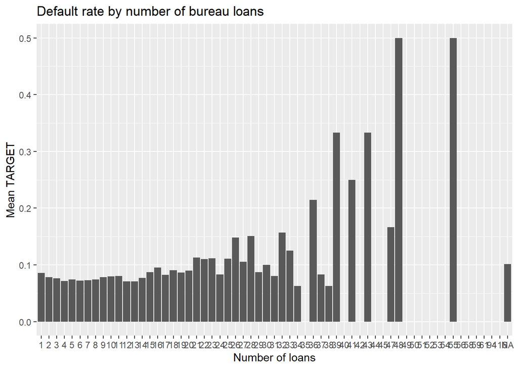

```r
library(dplyr)
library(ggplot2)

# Aggregate bureau data to applicant level
bureau_agg <- bureau %>%
  group_by(SK_ID_CURR) %>%
  summarise(
    n_loans = n(),
    n_active = sum(CREDIT_ACTIVE == "Active", na.rm = TRUE),
    max_overdue = max(AMT_CREDIT_SUM_OVERDUE, na.rm = TRUE),
    .groups = "drop"
  )


# Join with application data
train_b <- left_join(train, bureau_agg, by = "SK_ID_CURR")
test_b  <- left_join(test,  bureau_agg, by = "SK_ID_CURR")



# Default rate by number of loans
ggplot(train_b, aes(x = as.factor(n_loans), y = TARGET)) +
  stat_summary(fun = mean, geom = "col") +
  labs(title = "Default rate by number of bureau loans", x = "Number of loans", y = "Mean TARGET")
```

[output not shown]

[output not shown]

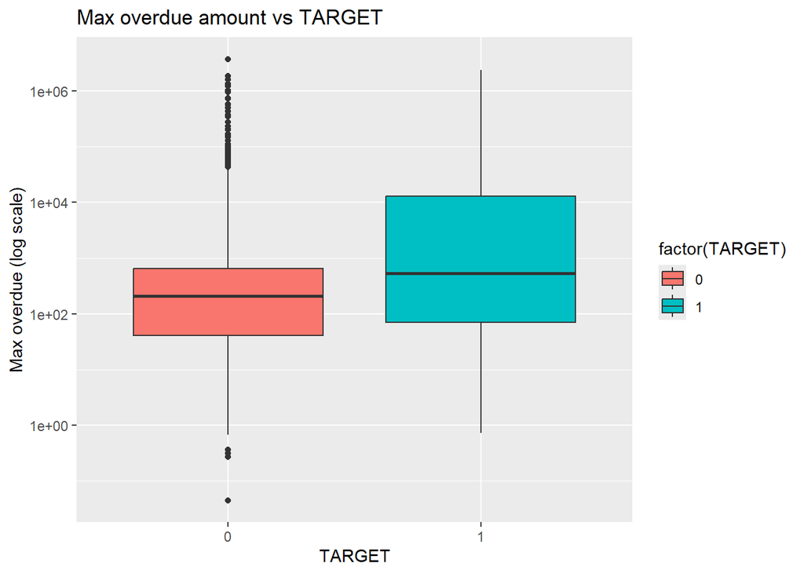

```r
# Max overdue vs TARGET
ggplot(train_b, aes(x = factor(TARGET), y = max_overdue, fill = factor(TARGET))) +
  geom_boxplot() +
  scale_y_log10() +
  labs(title = "Max overdue amount vs TARGET", x = "TARGET", y = "Max overdue (log scale)")
```

# Will the input data need to be transformed in order to be used in a model?

Yes, some transformations will be needed before modeling. Numeric variables like income and credit are very skewed, so they may need scaling or log transformation if I use models like logistic regression. Tree-based models can handle skew more easily, so they may not need this step.

Categorical variables such as education or occupation will need to be encoded into numbers for regression, while tree models can usually take them directly. Special cases like negative day counts (e.g., DAYS_BIRTH, DAYS_EMPLOYED) should be converted into positive years, and special codes like 365243 for “not employed” should be set to missing or recoded.

# Do some of the added columns show promise in predicting default?

# Summarize